# Black_Friday_Analysis

ShikuiWang

12/1/2018

#### The Black Friday of 2018 just passed, all stores were almost full of people and I also buy many items. So, I want to use what I learn from courses of Business Analytics program to explore something about Black Friday to not only have some insights of this Black Friday but also gain some practical experience of using R. The dataset here is a sample of the transactions made in a retail store. The store wants to know better the customer purchase behaviour against different products. However, all variables are labeled simply by number, without a specific defination. Hopefully we can still find some patterns behind the dataset.

#### The data is from https://www.kaggle.com/mehdidag/black-friday

## 1. Prepare the data

### 1.1 Load the data

```r
df <- read.csv("/Volumes/Shikui Wang/Dataset/BlackFriday.csv", stringsAsFactors = FALSE)
```

```r
# Because the dataset is very large, we only explore some part of it.
# Let's explore the part which doesn't contain missing values
df_complete <- df[complete.cases(df),]
sum(apply(df_complete, 2, is.na))
```

```
## [1] 0
```

```r
# No missing values now
```

### 1.2 Inspect data structure

```r
dim(df_complete)
```

```
## [1] 164278     12
```

```r
str(df_complete)
```

```
## 'data.frame':    164278 obs. of  12 variables:
##  $ User_ID                   : int  1000001 1000004 1000005 1000006 1000006 1000007 1000008 1000008 1000009 1000010 ...
##  $ Product_ID                : chr  "P00248942" "P00184942" "P00145042" "P00231342" ...
##  $ Gender                    : chr  "F" "M" "M" "F" ...
##  $ Age                       : chr  "0-17" "46-50" "26-35" "51-55" ...
##  $ Occupation                : int  10 7 20 9 9 1 12 12 17 1 ...
##  $ City_Category             : chr  "A" "B" "A" "A" ...
##  $ Stay_In_Current_City_Years: chr  "2" "2" "1" "1" ...
##  $ Marital_Status            : int  0 1 1 0 0 1 1 1 0 1 ...
##  $ Product_Category_1        : int  1 1 1 5 2 1 1 1 5 2 ...
##  $ Product_Category_2        : int  6 8 2 8 3 14 5 8 8 4 ...
##  $ Product_Category_3        : int  14 17 5 14 4 16 15 14 14 8 ...
##  $ Purchase                  : int  15200 19215 15665 5378 13055 11788 19614 11927 5391 16352 ...
```

```r
# The dataset contains 164278 rows and 12 columns, and all columns are categorical except User_ID, Product_ID, and Purchase
```

### 1.3 Clean and format data

```r
# We have to convert categorical variable to factor

df_complete$Gender <- as.factor(df_complete$Gender)
df_complete$Age <- as.factor(df_complete$Age)
df_complete$Occupation <- as.factor(df_complete$Occupation)
df_complete$City_Category <- as.factor(df_complete$City_Category)
df_complete$Stay_In_Current_City_Years <- as.factor(df_complete$Stay_In_Current_City_Years)
df_complete$Marital_Status <- as.factor(df_complete$Marital_Status)
df_complete$Product_Category_1 <- as.factor(df_complete$Product_Category_1)
df_complete$Product_Category_2 <- as.factor(df_complete$Product_Category_2)
df_complete$Product_Category_3 <- as.factor(df_complete$Product_Category_3)
# Now all categorical data has been changed to factor
str(df_complete)
```

```
## 'data.frame':    164278 obs. of  12 variables:
##  $ User_ID                   : int  1000001 1000004 1000005 1000006 1000006 1000007 1000008 1000008 1000009 1000010 ...
##  $ Product_ID                : chr  "P00248942" "P00184942" "P00145042" "P00231342" ...
##  $ Gender                    : Factor w/ 2 levels "F","M": 1 2 2 1 1 2 2 2 2 1 ...
##  $ Age                       : Factor w/ 7 levels "0-17","18-25",..: 1 5 3 6 6 4 3 3 3 4 ...
##  $ Occupation                : Factor w/ 21 levels "0","1","2","3",..: 11 8 21 10 10 2 13 13 18 2 ...
##  $ City_Category             : Factor w/ 3 levels "A","B","C": 1 2 1 1 1 2 3 3 3 2 ...
##  $ Stay_In_Current_City_Years: Factor w/ 5 levels "0","1","2","3",..: 3 3 2 2 2 2 5 5 1 5 ...
##  $ Marital_Status            : Factor w/ 2 levels "0","1": 1 2 2 1 1 2 2 2 1 2 ...
##  $ Product_Category_1        : Factor w/ 12 levels "1","2","3","4",..: 1 1 1 5 2 1 1 1 5 2 ...
##  $ Product_Category_2        : Factor w/ 14 levels "2","3","4","5",..: 5 6 1 6 2 12 4 6 6 3 ...
##  $ Product_Category_3        : Factor w/ 15 levels "3","4","5","6",..: 11 14 3 11 2 13 12 11 11 5 ...
##  $ Purchase                  : int  15200 19215 15665 5378 13055 11788 19614 11927 5391 16352 ...
```

```r
# All done, now we can explore the data
# Although those categorical data is labeled by number, hopefully we can explore it to reveal some secrets:)
# I am mainly interested in age, gender, occupation, city category and year of staying in city
library(dplyr)
```

```r
library(ggplot2)
library(scales)
```

## 2. Preliminary Exploratory

#### We first conduct preliminary data analysis to have a glimpse of data, and get some insights about this retail store

### 2.1 Gender

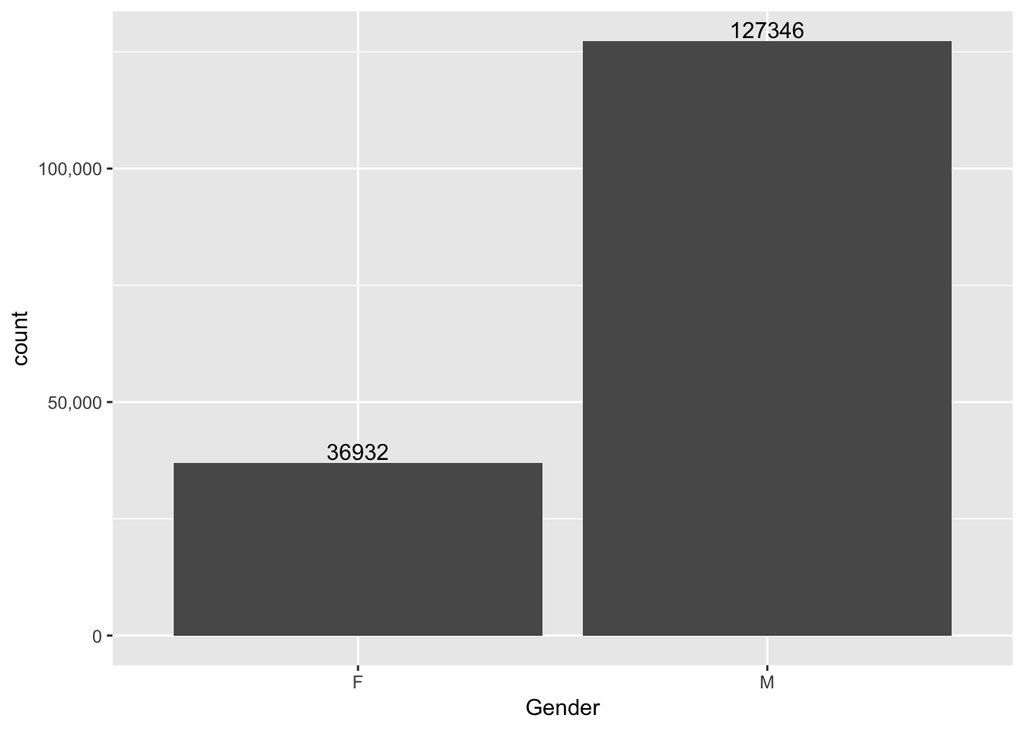

```r
ggplot(df_complete, aes(Gender)) + geom_bar() + scale_y_continuous(expand = c(0, 0)) +
  geom_text(aes(label=..count..),stat='count',position=position_dodge(0.9), vjust=-0.2) + ylim(0,140000) + scale_y_continuous(labels = comma)
```

```r
# Male is much more than female, implying this store may be selling things men are interested in
```

### 2.2 Age

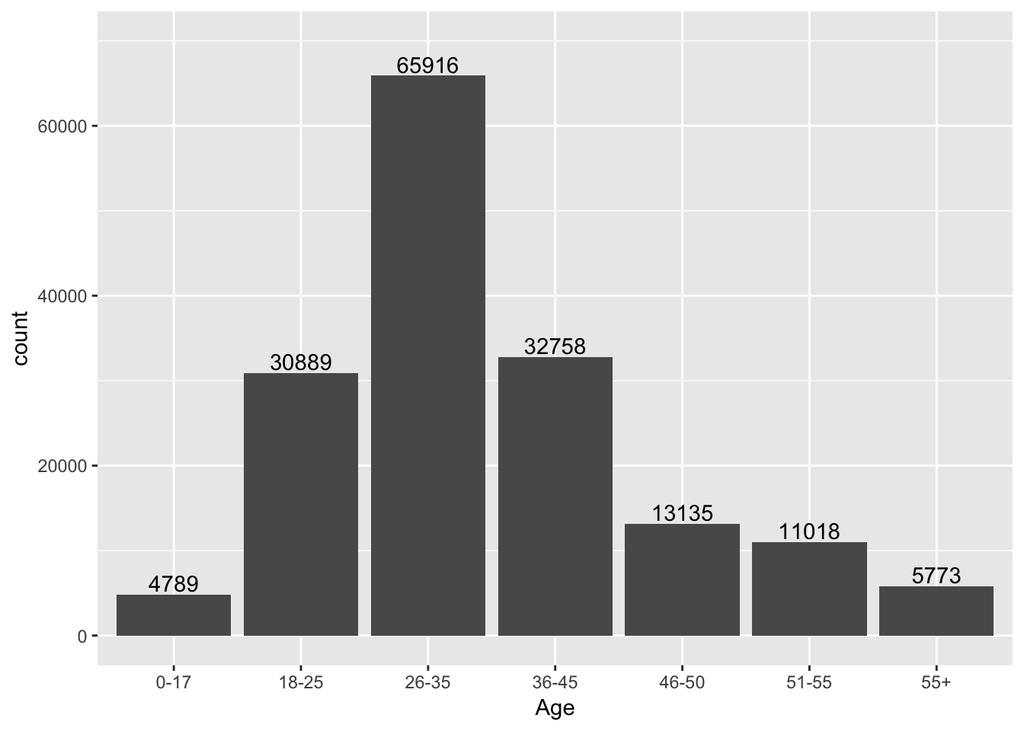

```r
ggplot(df_complete, aes(Age)) + geom_bar() + scale_y_continuous(expand = c(0, 0)) +
  geom_text(aes(label=..count..),stat='count',position=position_dodge(0.9), vjust=-0.2) + ylim(0,70000)
```

```r
# We can see most customer are of age 18-45, which means this is neither a toy store nor a pharmacy, something like that
```